# ESM 204 Homework 4

Jordan Faires and Evan Heberlein

5/27/2020

### 1. Plotting Temperature, Consumption and Utility

1. Plot temperature over time for no climate change, moderate climate change and extreme climate change.

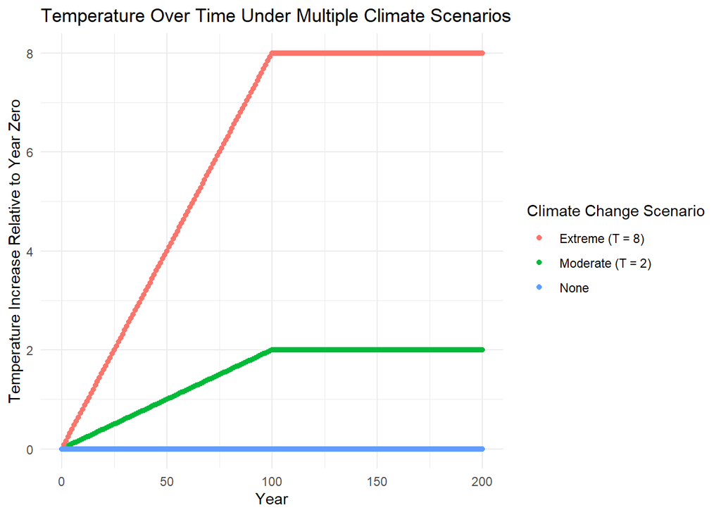

2. Plot consumption over time for no climate change, moderate climate change and extreme climate change.

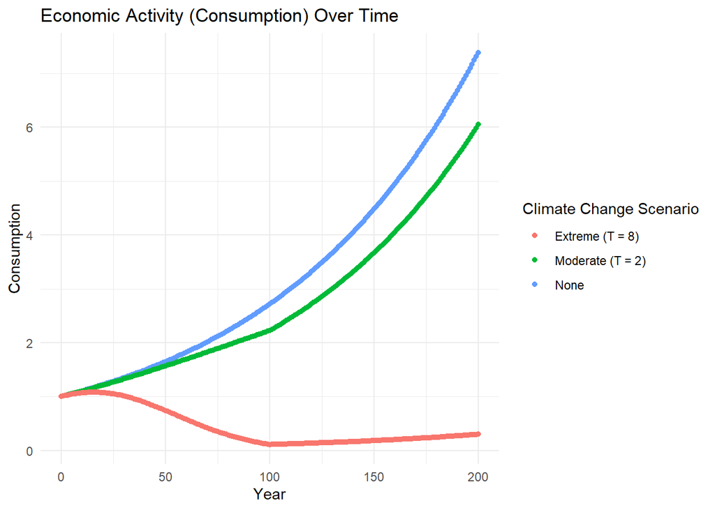

3. Plot undiscounted utility over time for for no climate change, moderate climate change and extreme climate change.

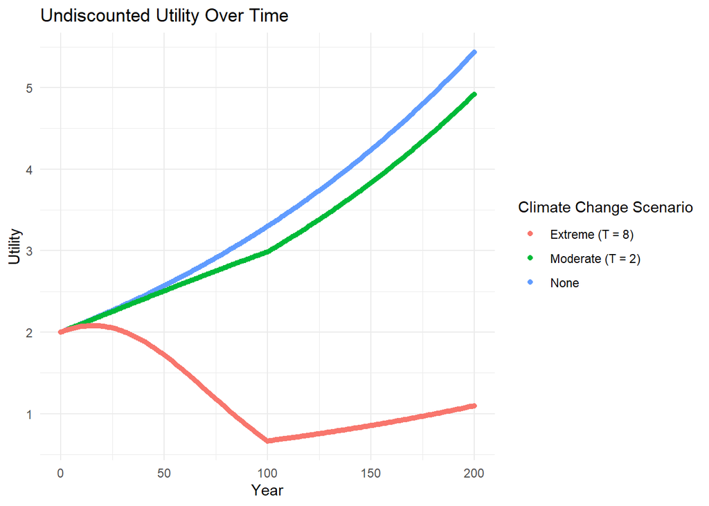

### 2. Analysis

#### 2.a - Calculating present value

The present value of the utility of consumption over the next 200 years under a 4.4$^\circ$C warming scenario is 198.6612197. This present value when evaluated with no warming is 255.2734418. These values are given by calculating the utility of consumption using the provided formulas, discounting these values to present values at each year from 0 to 200 according to the formula *V$_0$ = V$_t$/(1+r)<sup>t</sup>* (where *r* is the discount rate - in this case 0.01), and summing these values over the 200 year period.

*L* - the percent of total discounted utility lost on account of this 4.4$^\circ$C warming compared to the baseline scenario, is 22.1770904%.

~

#### 2.b - Sensitivity analysis

A sensitivity analysis of various modeling variables was conducted, by simulating a 10% increase in variables *T, g, $\eta$, and $\beta$*.

The percent change in *L* in response to a 10% increase in temperature *T* is -16.3217768% (elasticity of change in *L* to 10% change in *T* ($\epsilon$) = -1.6321777)

The sensitivity of *L* to a 10% increase in *g* is 13.2060522% ($\epsilon$ = 1.3206052)

The sensitivity of *L* to a 10% increase in *$\eta$* is 33.7998175% ($\epsilon$ = 3.3799817)

The sensitivity of *L* to a 10% increase in *$\beta$* is -7.9429826% ($\epsilon$ = -0.7942983)

~

#### 2.c - Calculating $\Theta$<sup>$*$</sup>

In order to find he maximum percentage of consumption that society would be willing to forego to avert a global temperature increase ($\Theta$<sup>$*$</sup>), we must find the value for ($\Theta$) that sets the net present value (NPV) of the utility function for a temperature increase of zero as equal to the NPV of the utility function for a temperature increase of 4.4. In other words the sum of *U($\Theta$ x C$_0$(t))* from *t(0)* to *t(200)* equals *U(C$_4._4$(t))* over the same interval. This can be algebraically simplified to *$\Theta$ = (NPV$_4._4$ / NPV$_0$) ^ (1 / 1 - $\eta$)*. $\Theta$<sup>$*$</sup> is then given by 1 - $\Theta$. This was solved by inserting previously calculated NPV$_4._4$ and NPV$_0$.

$\Theta$<sup>$*$</sup> = 39.4359475%

~

#### 2.d - $\Theta$<sup>$*$</sup> under temperature uncertainty

The expected NPV of this uncertain temperature scenario is 201.3446773%. This was found by calculating NPV at temperature increases of 2$^\circ$C, 4$^\circ$C and 6$^\circ$C, and multiplying this by the relative probability of these increases (20%, 50% and 30% respectively). This expected NPV of utility was then used in our equation to calculate $\Theta$<sup>$*$</sup> under temperature uncertainty, resulting in a $\Theta$<sup>$*$</sup>$_U$ of 37.7887341%.